# Дамми и категориальные переменные в R

Константин Житков

### Базовые настройки

Начнем с технического момента: установим несколько настроек, чтобы получить итоговый документ без информации о его создании, а также подключим библиотеки для построения графиков и работы с факторными переменными (о том, что такое факторные переменные будет сказано чуть ниже).

```r
knitr::opts_chunk$set(warning = FALSE)  # убрать предупреждения из документа
knitr::opts_chunk$set(message = FALSE)  # убрать сообщения из документа
```

```r
library("ggplot2")  # построение графиков
library("forcats")  # работа с факторными переменными
```

### Самый просто способ создания дамми переменной (индикатора)

Загрузим данные для построения примеров:

```r
data <- mtcars
```

### Категориальная переменная с двумя уровнями

```r
dummy1 <- ifelse(mtcars$hp > 90, "категория1", "категория2")
table(dummy1)
```

```
## dummy1
## категория1 категория2
##         27          5
```

### Простой индикатор

```r
dummy2 <- ifelse(mtcars$hp > 90, 1, 0)
table(dummy2)
```

```
## dummy2
##  0  1
##  5 27
```

### Функция `factor()`

В R дамми и категориальные переменные обычно представляются с помощью факторных переменных. По своей сути переменная типа фактор это числовой (numeric или integer) или текстовый вектор (character) с группировкой каждого уникального значения по категориям/уровням (levels).

Принцип работы команды проще понять с помощью примеров. Уровни (levels) автоматически устанавливаются на основе уникальных значений:

```r
fact1 <- factor(c(1, 1, 2))
fact2 <- factor(c("one", "one", "two"))

fact1
```

```
## [1] 1 1 2
## Levels: 1 2
```

```r
fact2
```

```
## [1] one one two
## Levels: one two
```

Уровням можно давать свои имена. Значения уровней (levels) получены из вектора лэйблов (labels):

```r
fact <- factor(c(1, 1, 2), labels = c("foo", "bar"))

fact
```

```
## [1] foo foo bar
## Levels: foo bar
```

Уровни (levels) указаны, но вектор содержит только NA: дело в том, что если уровни (levels) выставлены, то предполагается, что вектор содержит именно эти значения. R пытается найти их в векторе, но не находит и сохраняет заданные значения уровней (levels), отмечая, что наблюдений таких категорий у нас нет:

```r
fact <- factor(c(1, 1, 2), levels = c("foo", "bar"))

fact
```

```
## [1] <NA> <NA> <NA>
## Levels: foo bar
```

Пример возможного использования команды `levels`:

```r
fact1 <- factor(c(1, 1, 2), levels = c("1", "2"))
fact2 <- factor(c(1, 1, 2), levels = c("1", "2", "3"))
```

В первом случае мы прописали руками то, что R делает автоматически (создание категорий (уровней/levels) на основе уникальных значений):

```r
fact1
```

```
## [1] 1 1 2
## Levels: 1 2
```

Во втором случае одному из уровней (level) не соответствует ни одного наблюдения:

```r
fact2
```

```
## [1] 1 1 2
## Levels: 1 2 3
```

### Изменение названий уровней

Иногда нам не нравятся названия уровней (levels), полученные на основе уникальных значений вектора. Разберёмся с тем, как переименовать их.

Создаём фактор с уровнями (levels) “1” и “2”. Проверяем, что они действительно такие с помощью функции `levels()`:

```r
fact <- factor(c(1, 1, 2))
levels(fact)
```

```
## [1] "1" "2"
```

Переименовать их в “one” и “two” можно с помощью той же функции `levels()`. Но есть и другой способ. Вернёмся к самому началу заметки. В одном из первых блоков кода мы загрузили пакет `forcats`. Эта библиотека представляет собой обширную коллекцию функций для манипулирования факторами. Да, все операции с факторными переменными можно сделать, пользуясь базовыми командами или придумывая свои функции, но для большинства стандартных случаев можно воспользоваться готовым решением. Далее в заметке будут приведены манипуляции с факторами на основе как базовых команд R, так и команд из пакета `forcats`.

```r
fact <- factor(c(1, 1, 2))
levels(fact) <- c("one", "two")

fact
```

```
## [1] one one two
## Levels: one two
```

`forcats` решение. Результат идентичный, но запись команды позволяет лучше контролировать соответствие новых уровней старым:

```r
fact <- factor(c(1, 1, 2))
fact <- fct_recode(fact, one = "1", two = "2")

fact
```

```
## [1] one one two
## Levels: one two
```

### Удаление пустых уровней

Часто после сортировки и фильтрации данных некоторые наблюдения удаляются из выборки. Может так случиться, что теперь какому-то из уровней (level) факторной переменной не соответсвует ни одного наблюдения. Чтобы не таскать за собой эту информацию можно воспользоваться функцией `droplevels()`.

Тоже самое на примере. Создаём фактор:

```r
fact <- factor(c(1, 1, 2))
```

Удаляем одно наблюдение:

```r
fact <- fact[1:2]
```

Теперь у нас есть один **неиспользованный** уровень (level). Удалим его:

```r
fact <- droplevels(fact)
fact
```

```
## [1] 1 1
## Levels: 1
```

Или `forcats` решение:

```r
fact <- fct_drop(fact)
fact
```

```
## [1] 1 1
## Levels: 1
```

### Изменение порядка уровней

Ещё одной ситуацией требующей манипуляции над факторной переменной является построение регрессии. Мы часто хотим, чтобы **базовой** категорией была какая-то определенная (женщина, а не мужчина, общее образование, а не среднепрофессиональное etc.). Установить такую категорию несложно:

```r
fact <- factor(c(1, 1, 2, 3))
fact <- relevel(fact, ref = "2")
```

Теперь “2” стоит в начале:

```r
fact
```

```
## [1] 1 1 2 3
## Levels: 2 1 3
```

Функция `relevel` из пакета `stats`, которой мы только что воспользовались позволяет перенести в начало лишь *один* уровень. Если нужно перенести в начало несколько уровней, то нужно пользоваться функцией `fct_relevel`.

На примере:

```r
fact <- factor(c(1, 1, 2, 3))
fact <- fct_relevel(fact, "2", "3")
```

Теперь “2” и “3” стоят в начале:

```r
fact
```

```
## [1] 1 1 2 3
## Levels: 2 3 1
```

Кроме как в регрессии подобная манипуляция выручает, если требуется расположить элементы на графике в определенном порядке. Создаём базовый график. “0” означает, что коробка передач в автомобиле автоматическая, “1” соответствует механической коробке.

```r
# В самом начале главы мы записали данные mtcars в переменную data

# Переведем числовые (numeric) переменные в factor
data$cyl <- factor(data$cyl)
data$am <- factor(data$am)

# Посмотрим, что вышло
table(data$cyl)
```

```
##
##  4  6  8
## 11  7 14
```

```r
table(data$am)
```

```
##
##  0  1
## 19 13
```

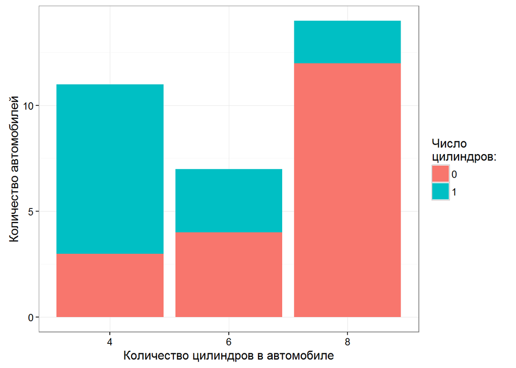

```r
# Построим график
bar_fill <- ggplot(data = data, aes(x = cyl, fill = am)) +
  geom_bar() +
  scale_fill_discrete(name = "Число\nцилиндров:") +
  labs(x = "Количество цилиндров в автомобиле",
       y = "Количество автомобилей") +
  theme_bw()

bar_fill
```

Допустим, мы хотим, чтобы в легенде сначала отображалась механическая коробка передач. Применяем функцию `fct_relevel` и строим график заново (код для графика не изменился, но, обновились данные, чтобы отобразить эти изменения мы дублируем код для графика):

```r
# Меняем порядок уровней
data$am <- fct_relevel(data$am, "1", "0")
table(data$am)
```

```
##
##  1  0
## 13 19
```

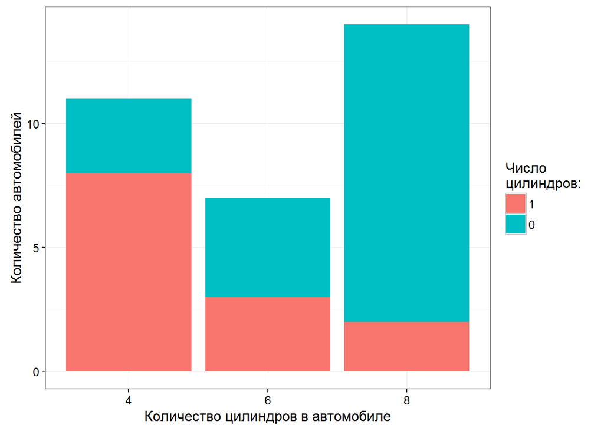

```r
# Строим график
bar_fill <- ggplot(data = data, aes(x = cyl, fill = am)) +
  geom_bar() +
  scale_fill_discrete(name = "Число\nцилиндров:") +
  labs(x = "Количество цилиндров в автомобиле",
       y = "Количество автомобилей") +
  theme_bw()
bar_fill
```

### Объединение редких уровней (levels) в одну категорию (“другое”)

Предположим, что на один из вопросов из социологического опроса есть 5 вариантов ответа и большинство людей остановились на первых трёх: 100 человек выбрали первый, 200 второй, 150 третий, 10 четвертый и 7 пятый. Последние два варинта ответа редкие и говорят о каких-то необычных активностях. Такая детализация не всегда нужна, поэтому можно объединить их в одну категорию, к примеру, “другое”.

Такие действия приходится производить достаточно часто и поэтому в пакете `forcats` есть функция для этого.

### Пример с объединением категорий

Собираем редкие уровни в категорию “other”. `n` задаёт количество уровней, которые нужно оставить: допустим у нашего фактора 5 уровней, мы считаем, что 2 из них редкие, тогда мы задаём `n=3` и получаем четвертый уровень, названный в соответствии с аргументом `other_level`.

Создаём фактор с редкими категориями:

```r
fact <- factor(c(rep("c", 100), rep("g", 2), rep("j", 4), rep("r", 3), rep("v", 10)))
table(fact)
```

```
## fact
##   c   g   j   r   v
## 100   2   4   3  10
```

Оставляем 3 самых частых уровня (levels), четвертый называем “other”:

```r
fact <- fct_lump(fact, n = 3, other_level = "other")
table(fact)
```

```
## fact
##     c     j     v other
##   100     4    10     5
```

### Пример с столбиковым графиком (bar plot)

Когда в факторной переменной много уровней (допустим > 8), могут начаться проблемы с построением столбиковых графиков: подписи осей будут накладываться друг на друга (не всегда категории названы “a”), восприятие диаграммы будет осложнено избытком информации. Чтобы избежать этого достаточно объединить редкие категории (уровни/levels) в одну.

Создаём искуственный набор данных:

```r
d <- data.frame(v1 = seq(1:100),
                v2 = factor(c(rep("a", 40),
                              rep("b", 20),
                              rep("c", 20),
                              rep("d", 6),
                              rep("e", 5),
                              rep("f", 3),
                              rep("g", 3),
                              rep("h", 2),
                              rep("i", 1))))
```

Посмотрим на то, что получилось. v2 — это фактор с 9 уровнями (levels):

```r
table(d$v2)
```

```
##
##  a  b  c  d  e  f  g  h  i
## 40 20 20  6  5  3  3  2  1
```

Столбиковый график (bar plot) v2, до объединения редких уровней (levels):

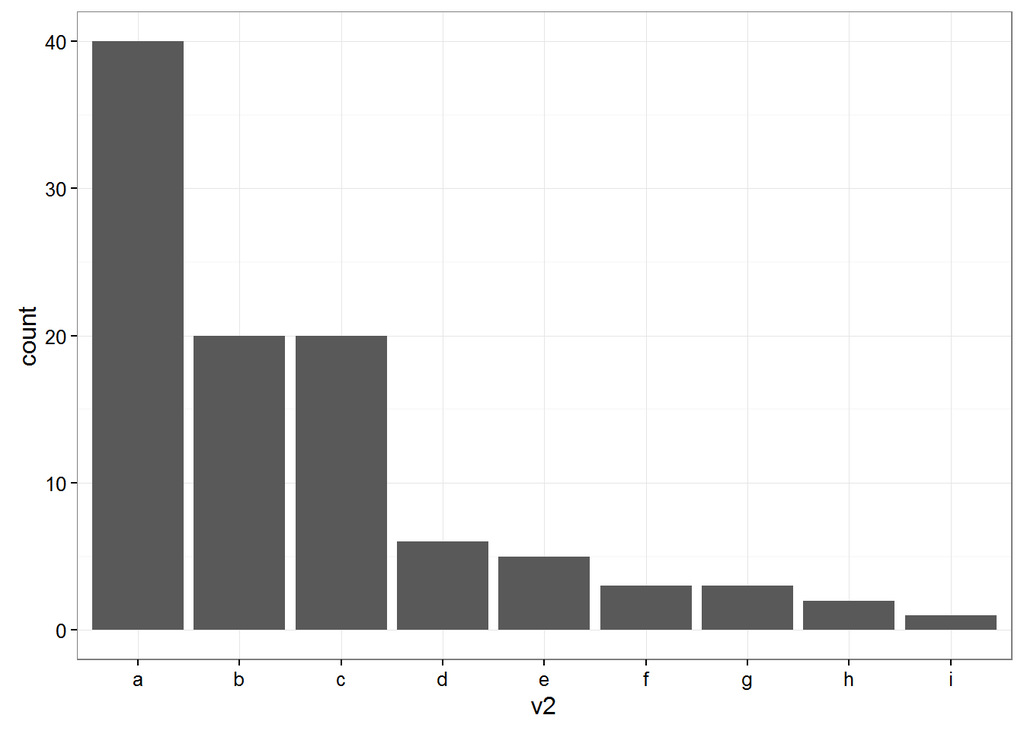

```r
before<- ggplot(data = d, aes(x = v2)) +
  geom_bar() +
  theme_bw()
before
```

Модифицируем v2: объединим редкие уровни (levels) в один под названием “other”. Теперь v2 это фактор с 6 уровнями (levels), один из которых называется `other`. *Внимание*: `n = 5` значит, что мы хотим сохранить 5 самых частых уровней (other), а оставшиеся объединить в новый, поэтому в результате получится 6 уровней:

```r
d$v2 <- fct_lump(d$v2, n = 5, other_level = "other")
table(d$v2)
```

```
##
##     a     b     c     d     e other
##    40    20    20     6     5     9
```

Столбиковый график (bar plot) после объединения редких уровней (levels):

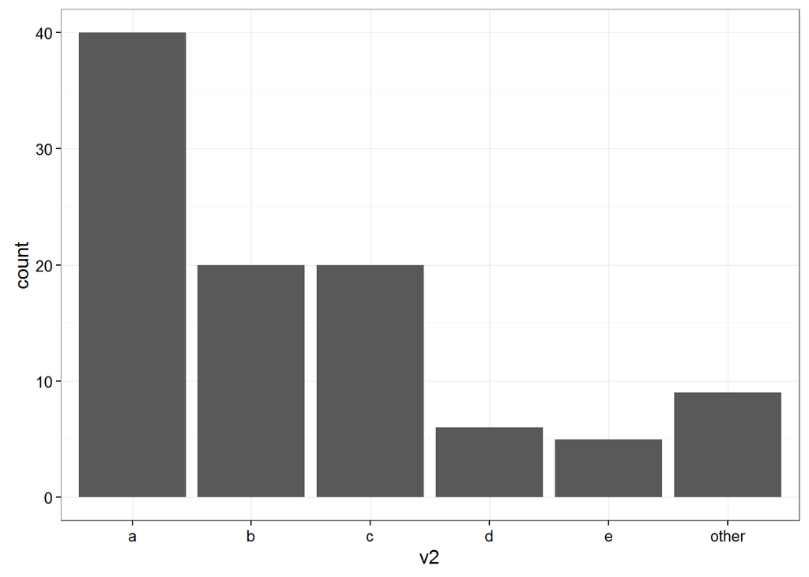

```r
after <- ggplot(data = d, aes(x = v2)) +
  geom_bar() +
  theme_bw()
after
```

### PS

Дополнительные примеры задач, которые могут возникнуть при работе с факторными переменными можно найти в документации к пакету `forcats`.